# Supply Chain Analytics – Demand Forecasting & Anomaly Detection

## Day 5 - Feature Engineering + Time-Series Preparation

```python
#import required libraries

import pandas as pd
import numpy as np
import matplotlib.pyplot as plt
import seaborn as sns

from statsmodels.tsa.seasonal import seasonal_decompose

pd.set_option("display.max_columns", None)
pd.set_option("display.float_format", lambda x: f"{x:.2f}")
```

```python
#load cleaned dataset

file_path = r"C:\Users\LENOVO\Desktop\Supply-Chain-Demand-Forecasting-Anomaly-Detection\data\processed\supply_chain_cleaned.csv"

df = pd.read_csv(file_path)

print("Dataset Loaded Successfully")
print("Rows    :", df.shape[0])
print("Columns :", df.shape[1])
print("\nColumn Names:\n")
print(df.columns.tolist())
```

```
Dataset Loaded Successfully
Rows    : 91250
Columns : 15

Column Names:

['Date', 'SKU_ID', 'Warehouse_ID', 'Supplier_ID', 'Region', 'Units_Sold', 'Inventory_Level', 'Supplier_Lead_Time_Days', 'Reorder_Point', 'Order_Quantity', 'Unit_Cost', 'Unit_Price', 'Promotion_Flag', 'Stockout_Flag', 'Demand_Forecast']
```

```python
#convert date column

df["Date"] = pd.to_datetime(df["Date"])

df = df.sort_values(
    ["SKU_ID", "Warehouse_ID", "Date"]
).reset_index(drop=True)

print("Date Conversion Completed")
print("\nData Type:")
print(df["Date"].dtype)

print("\nDate Range:")
print("Start Date :", df["Date"].min().date())
print("End Date   :", df["Date"].max().date())
```

```
Date Conversion Completed

Data Type:
datetime64[us]

Date Range:
Start Date : 2024-01-01
End Date   : 2024-12-30
```

```python
#check time series structure

print("Unique Dates          :", df["Date"].nunique())
print("Unique SKUs           :", df["SKU_ID"].nunique())
print("Unique Warehouses     :", df["Warehouse_ID"].nunique())

print("\nRecords per Date:")
print(df.groupby("Date").size().describe())

print("\nDuplicate SKU-Warehouse-Date combinations:")
duplicate_time_keys = df.duplicated(
    subset=["SKU_ID", "Warehouse_ID", "Date"]
).sum()

print(duplicate_time_keys)
```

```
Unique Dates          : 365
Unique SKUs           : 50
Unique Warehouses     : 5

Records per Date:
count   365.00
mean    250.00
std       0.00
min     250.00
25%     250.00
50%     250.00
75%     250.00
max     250.00
dtype: float64

Duplicate SKU-Warehouse-Date combinations:
0
```

```python
#aggregate daily demand

daily_demand = df.groupby("Date")["Units_Sold"].sum().reset_index()

daily_demand.columns = ["Date", "Total_Demand"]

print("Daily Demand Shape :", daily_demand.shape)
print("\nFirst 5 Days:")
print(daily_demand.head())

print("\nLast 5 Days:")
print(daily_demand.tail())
```

```
Daily Demand Shape : (365, 2)

First 5 Days:
        Date  Total_Demand
0 2024-01-01          5054
1 2024-01-02          5072
2 2024-01-03          5278
3 2024-01-04          5144
4 2024-01-05          5208

Last 5 Days:
          Date  Total_Demand
360 2024-12-26          4785
361 2024-12-27          4895
362 2024-12-28          4944
363 2024-12-29          5000
364 2024-12-30          5023
```

```python
# Cross-check
print("Unique Dates in Daily Demand :", daily_demand["Date"].nunique())
```

```
Unique Dates in Daily Demand : 365
```

```python
# Weekly and monthly demand aggregation
#resample demand

daily_demand["Date"] = pd.to_datetime(daily_demand["Date"])

weekly_demand = (
    daily_demand
    .set_index("Date")["Total_Demand"]
    .resample("W")
    .sum()
)

monthly_demand = (
    daily_demand
    .set_index("Date")["Total_Demand"]
    .resample("ME")
    .sum()
)

print("Weekly Demand Records  :", len(weekly_demand))
print("Monthly Demand Records :", len(monthly_demand))

print("\nWeekly Demand:")
print(weekly_demand.head())

print("\nMonthly Demand:")
print(monthly_demand.head())
```

```
Weekly Demand Records  : 53
Monthly Demand Records : 12

Weekly Demand:
Date
2024-01-07    36381
2024-01-14    38372
2024-01-21    40662
2024-01-28    42464
2024-02-04    44187
Freq: W-SUN, Name: Total_Demand, dtype: int64

Monthly Demand:
Date
2024-01-31    176681
2024-02-29    197188
2024-03-31    231596
2024-04-30    223793
2024-05-31    210841
Freq: ME, Name: Total_Demand, dtype: int64
```

```python
# Cross-check
print("Expected Monthly Records :", daily_demand["Date"].dt.to_period("M").nunique())
```

```
Expected Monthly Records : 12
```

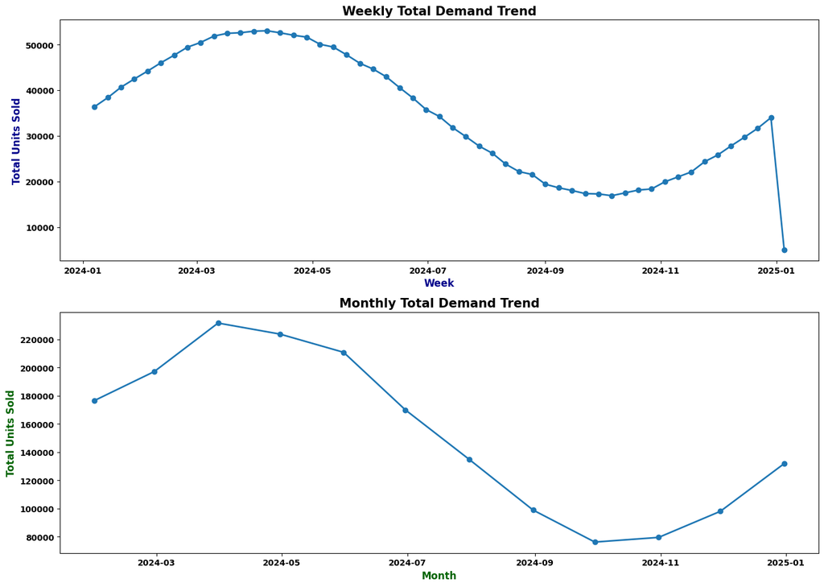

```python
# Weekly & monthly demand visualization
#visualize demand trends

fig, axes = plt.subplots(2, 1, figsize=(14, 10))

axes[0].plot(
    weekly_demand.index,
    weekly_demand.values,
    marker="o",
    linewidth=2
)

axes[0].set_title(
    "Weekly Total Demand Trend",
    fontsize=15,
    fontweight="bold"
)
axes[0].set_xlabel(
    "Week",
    fontsize=12,
    fontweight="bold",
    color="darkblue"
)
axes[0].set_ylabel(
    "Total Units Sold",
    fontsize=12,
    fontweight="bold",
    color="darkblue"
)

axes[0].tick_params(axis="both", labelsize=10)
for label in axes[0].get_xticklabels() + axes[0].get_yticklabels():
    label.set_fontweight("bold")


axes[1].plot(
    monthly_demand.index,
    monthly_demand.values,
    marker="o",
    linewidth=2
)

axes[1].set_title(
    "Monthly Total Demand Trend",
    fontsize=15,
    fontweight="bold"
)
axes[1].set_xlabel(
    "Month",
    fontsize=12,
    fontweight="bold",
    color="darkgreen"
)
axes[1].set_ylabel(
    "Total Units Sold",
    fontsize=12,
    fontweight="bold",
    color="darkgreen"
)

axes[1].tick_params(axis="both", labelsize=10)
for label in axes[1].get_xticklabels() + axes[1].get_yticklabels():
    label.set_fontweight("bold")

plt.tight_layout()
plt.show()
```

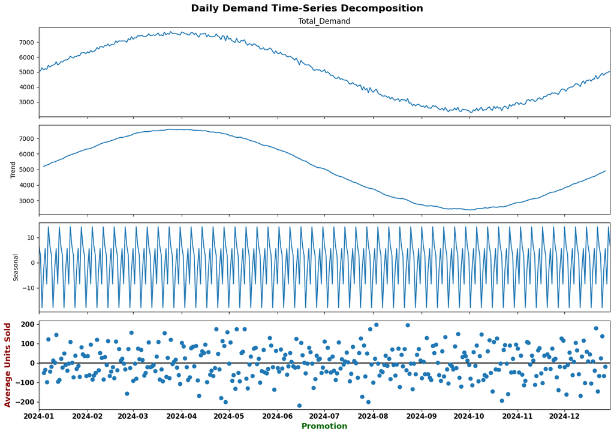

```python
# Time-series decomposition
#decompose time series

from statsmodels.tsa.seasonal import seasonal_decompose

daily_series = daily_demand.set_index("Date")["Total_Demand"]

decomposition = seasonal_decompose(
    daily_series,
    model="additive",
    period=7
)

fig = decomposition.plot()

fig.set_size_inches(14, 10)

fig.suptitle(
    "Daily Demand Time-Series Decomposition",
    fontsize=16,
    fontweight="bold"
)

plt.xlabel(
    "Promotion",
    fontsize=13,
    fontweight="bold",
    color="darkgreen"
)

plt.ylabel(
    "Average Units Sold",
    fontsize=13,
    fontweight="bold",
    color="darkred"
)

# X-axis values dark & bold
plt.xticks(
    fontsize=11,
    fontweight="bold",
    color="black"
)

# Y-axis values dark & bold
plt.yticks(
    fontsize=11,
    fontweight="bold",
    color="black"
)
plt.tight_layout()
plt.show()
```

```python
# Day-wise demand pattern
#analyze weekly seasonality

daily_demand["Day"] = daily_demand["Date"].dt.day_name()

day_order = [
    "Monday", "Tuesday", "Wednesday",
    "Thursday", "Friday", "Saturday", "Sunday"
]

daywise_demand = (
    daily_demand.groupby("Day")["Total_Demand"]
    .mean()
    .reindex(day_order)
)

print("Average Demand by Day:")
print(daywise_demand)
```

```
Average Demand by Day:
Day
Monday      5020.02
Tuesday     5015.56
Wednesday   4998.63
Thursday    5010.12
Friday      5018.87
Saturday    5004.92
Sunday      5027.25
Name: Total_Demand, dtype: float64
```

```python
# Cross-check
print("\nNumber of Days Analyzed :", daywise_demand.count())
```

```
Number of Days Analyzed : 7
```

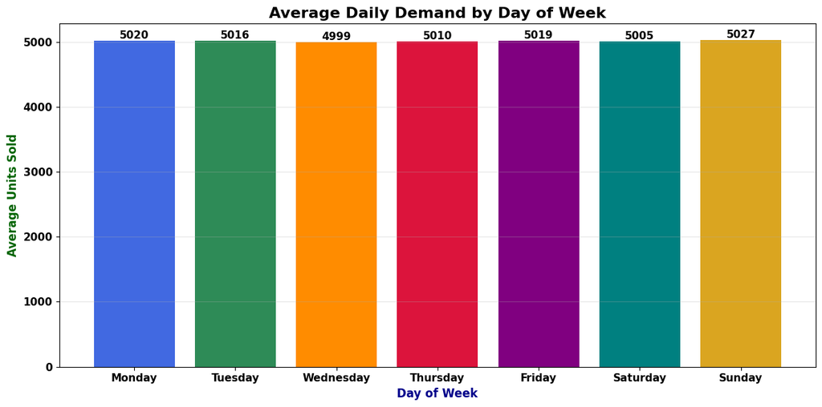

```python
# Day-wise seasonal visualization
# visualize weekly seasonality

plt.figure(figsize=(12, 6))

colors = [
    "royalblue",
    "seagreen",
    "darkorange",
    "crimson",
    "purple",
    "teal",
    "goldenrod"
]

bars = plt.bar(
    daywise_demand.index,
    daywise_demand.values,
    color=colors
)

plt.title(
    "Average Daily Demand by Day of Week",
    fontsize=16,
    fontweight="bold",
    color="black"
)

plt.xlabel(
    "Day of Week",
    fontsize=12,
    fontweight="bold",
    color="darkblue"
)

plt.ylabel(
    "Average Units Sold",
    fontsize=12,
    fontweight="bold",
    color="darkgreen"
)

# Dark and bold X-axis ticks
plt.xticks(
    fontsize=11,
    fontweight="bold",
    color="black"
)

# Dark and bold Y-axis ticks
plt.yticks(
    fontsize=11,
    fontweight="bold",
    color="black"
)

# Show values on bars
for bar, value in zip(bars, daywise_demand.values):
    plt.text(
        bar.get_x() + bar.get_width() / 2,
        bar.get_height(),
        f"{value:.0f}",
        ha="center",
        va="bottom",
        fontsize=11,
        fontweight="bold",
        color="black"
    )

plt.grid(
    axis="y",
    alpha=0.3
)

plt.tight_layout()
plt.show()
```

```python
# Inventory trend analysis
# analyze inventory trend

daily_inventory = (
    df.groupby("Date")["Inventory_Level"]
    .mean()
    .reset_index()
)

daily_inventory["Date"] = pd.to_datetime(daily_inventory["Date"])

print("Daily Inventory Shape :", daily_inventory.shape)

print("\nAverage Inventory:")
print(daily_inventory["Inventory_Level"].mean())

print("\nMinimum Daily Average Inventory:")
print(daily_inventory["Inventory_Level"].min())

print("\nMaximum Daily Average Inventory:")
print(daily_inventory["Inventory_Level"].max())
```

```
Daily Inventory Shape : (365, 2)

Average Inventory:
471.5223123287671

Minimum Daily Average Inventory:
435.852

Maximum Daily Average Inventory:
721.316
```

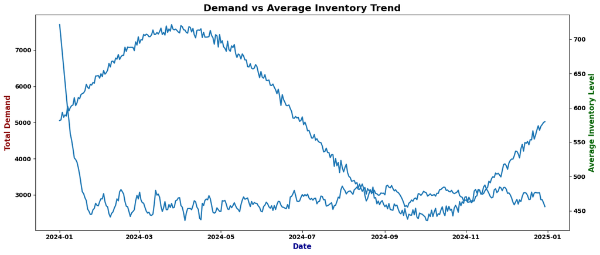

```
Comparison Shape : (365, 4)
Date Match Check : 365
```

```python
# Demand vs Inventory trend
# compare demand and inventory

comparison_df = daily_demand.merge(
    daily_inventory,
    on="Date",
    how="inner"
)

fig, ax1 = plt.subplots(figsize=(14, 6))

ax1.plot(
    comparison_df["Date"],
    comparison_df["Total_Demand"],
    linewidth=2,
    label="Total Demand"
)

ax1.set_xlabel(
    "Date",
    fontsize=12,
    fontweight="bold",
    color="darkblue"
)

ax1.set_ylabel(
    "Total Demand",
    fontsize=12,
    fontweight="bold",
    color="darkred"
)

ax1.tick_params(axis="both", labelsize=10)

for label in ax1.get_xticklabels() + ax1.get_yticklabels():
    label.set_fontweight("bold")

ax2 = ax1.twinx()

ax2.plot(
    comparison_df["Date"],
    comparison_df["Inventory_Level"],
    linewidth=2,
    label="Average Inventory"
)

ax2.set_ylabel(
    "Average Inventory Level",
    fontsize=12,
    fontweight="bold",
    color="darkgreen"
)

ax2.tick_params(axis="y", labelsize=10)

for label in ax2.get_yticklabels():
    label.set_fontweight("bold")

plt.title(
    "Demand vs Average Inventory Trend",
    fontsize=16,
    fontweight="bold"
)

fig.tight_layout()
plt.show()

print("Comparison Shape :", comparison_df.shape)
print("Date Match Check :", comparison_df["Date"].nunique())
```

```python
# Date-based features
#date features

df["Year"] = df["Date"].dt.year
df["Month"] = df["Date"].dt.month
df["Week"] = df["Date"].dt.isocalendar().week.astype(int)
df["Day"] = df["Date"].dt.day
df["Day_of_Week"] = df["Date"].dt.dayofweek
df["Day_of_Year"] = df["Date"].dt.dayofyear
df["Is_Weekend"] = (df["Day_of_Week"] >= 5).astype(int)

print("Date Features Created Successfully")

print("\nNew Date Features:")
print([
    "Year",
    "Month",
    "Week",
    "Day",
    "Day_of_Week",
    "Day_of_Year",
    "Is_Weekend"
])

print("\nSample:")
print(
    df[
        [
            "Date",
            "Year",
            "Month",
            "Week",
            "Day",
            "Day_of_Week",
            "Day_of_Year",
            "Is_Weekend"
        ]
    ].head()
)
```

```
Date Features Created Successfully

New Date Features:
['Year', 'Month', 'Week', 'Day', 'Day_of_Week', 'Day_of_Year', 'Is_Weekend']

Sample:
        Date  Year  Month  Week  Day  Day_of_Week  Day_of_Year  Is_Weekend
0 2024-01-01  2024      1     1    1            0            1           0
1 2024-01-02  2024      1     1    2            1            2           0
2 2024-01-03  2024      1     1    3            2            3           0
3 2024-01-04  2024      1     1    4            3            4           0
4 2024-01-05  2024      1     1    5            4            5           0
```

```python
#demand lag features

group_cols = ["SKU_ID", "Warehouse_ID"]

df["Demand_Lag_1"] = (
    df.groupby(group_cols)["Units_Sold"]
      .shift(1)
)

df["Demand_Lag_7"] = (
    df.groupby(group_cols)["Units_Sold"]
      .shift(7)
)

df["Demand_Lag_14"] = (
    df.groupby(group_cols)["Units_Sold"]
      .shift(14)
)

df["Demand_Lag_30"] = (
    df.groupby(group_cols)["Units_Sold"]
      .shift(30)
)

print("Lag Features Created Successfully")

print("\nLag Feature Summary:")
print(
    df[
        [
            "Units_Sold",
            "Demand_Lag_1",
            "Demand_Lag_7",
            "Demand_Lag_14",
            "Demand_Lag_30"
        ]
    ].head(35)
)
```

```
Lag Features Created Successfully

Lag Feature Summary:
    Units_Sold  Demand_Lag_1  Demand_Lag_7  Demand_Lag_14  Demand_Lag_30
0           10           NaN           NaN            NaN            NaN
1           17         10.00           NaN            NaN            NaN
2           35         17.00           NaN            NaN            NaN
3           24         35.00           NaN            NaN            NaN
4           21         24.00           NaN            NaN            NaN
5           18         21.00           NaN            NaN            NaN
6           19         18.00           NaN            NaN            NaN
7           23         19.00         10.00            NaN            NaN
8           25         23.00         17.00            NaN            NaN
9           25         25.00         35.00            NaN            NaN
10          23         25.00         24.00            NaN            NaN
```

[output cut: 24 more lines]

```python
#rolling demand features

df["Demand_Rolling_Mean_7"] = (
    df.groupby(group_cols)["Units_Sold"]
      .transform(lambda x: x.shift(1).rolling(7).mean())
)

df["Demand_Rolling_Mean_14"] = (
    df.groupby(group_cols)["Units_Sold"]
      .transform(lambda x: x.shift(1).rolling(14).mean())
)

df["Demand_Rolling_Mean_30"] = (
    df.groupby(group_cols)["Units_Sold"]
      .transform(lambda x: x.shift(1).rolling(30).mean())
)

print("Rolling Features Created Successfully")

print("\nRolling Feature Summary:")
print(
    df[
        [
            "Units_Sold",
            "Demand_Rolling_Mean_7",
            "Demand_Rolling_Mean_14",
            "Demand_Rolling_Mean_30"
        ]
    ].head(35)
)
```

```
Rolling Features Created Successfully

Rolling Feature Summary:
    Units_Sold  Demand_Rolling_Mean_7  Demand_Rolling_Mean_14  \
0           10                    NaN                     NaN
1           17                    NaN                     NaN
2           35                    NaN                     NaN
3           24                    NaN                     NaN
4           21                    NaN                     NaN
5           18                    NaN                     NaN
6           19                    NaN                     NaN
7           23                  20.57                     NaN
8           25                  22.43                     NaN
9           25                  23.57                     NaN
10          23                  22.14                     NaN
```

[output cut: 61 more lines]

```python
# Supply-chain derived features
#derived supply chain features

df["Inventory_Demand_Ratio"] = (
    df["Inventory_Level"] /
    df["Demand_Rolling_Mean_7"].replace(0, np.nan)
)

df["Inventory_Gap"] = (
    df["Inventory_Level"] - df["Reorder_Point"]
)

df["Forecast_Error"] = (
    df["Units_Sold"] - df["Demand_Forecast"]
)

df["Absolute_Forecast_Error"] = (
    df["Forecast_Error"].abs()
)

print("Derived Features Created Successfully")

derived_cols = [
    "Inventory_Demand_Ratio",
    "Inventory_Gap",
    "Forecast_Error",
    "Absolute_Forecast_Error"
]

print("\nDerived Feature Summary:")
print(df[derived_cols].describe())
```

```
Derived Features Created Successfully

Derived Feature Summary:
       Inventory_Demand_Ratio  Inventory_Gap  Forecast_Error  \
count                89500.00       91250.00        91250.00
mean                    27.97         171.45           -0.03
std                     15.67         122.63            2.99
min                      5.22         -49.00          -14.08
25%                     16.56          71.00           -2.03
50%                     23.45         160.00           -0.01
75%                     35.61         258.00            1.99
max                    189.26         744.00           13.00

       Absolute_Forecast_Error
count                 91250.00
mean                      2.38
std                       1.81
min                       0.00
25%                       0.95
50%                       2.00
75%                       3.44
max                      14.08
```

```python
#final feature validation

print("Final Dataset Shape")
print("Rows    :", df.shape[0])
print("Columns :", df.shape[1])

print("\nMissing Values")
missing_values = df.isnull().sum()
print(missing_values[missing_values > 0])

print("\nTotal Missing Values :", df.isnull().sum().sum())

print("\nInfinite Values")
infinite_values = np.isinf(
    df.select_dtypes(include=np.number)
).sum().sum()

print("Total Infinite Values :", infinite_values)

print("\nDuplicate Rows")
print("Total Duplicate Rows :", df.duplicated().sum())

print("\nNew Feature Columns")
new_features = [
    "Year",
    "Month",
    "Week",
    "Day",
    "Day_of_Week",
    "Day_of_Year",
    "Is_Weekend",
    "Demand_Lag_1",
    "Demand_Lag_7",
    "Demand_Lag_14",
    "Demand_Lag_30",
    "Demand_Rolling_Mean_7",
    "Demand_Rolling_Mean_14",
    "Demand_Rolling_Mean_30",
    "Inventory_Demand_Ratio",
    "Inventory_Gap",
    "Forecast_Error",
    "Absolute_Forecast_Error"
]

print(new_features)
print("\nTotal New Features :", len(new_features))

print("\nData Types")
print(df[new_features].dtypes)
```

```
Final Dataset Shape
Rows    : 91250
Columns : 33

Missing Values
Demand_Lag_1               250
Demand_Lag_7              1750
Demand_Lag_14             3500
Demand_Lag_30             7500
Demand_Rolling_Mean_7     1750
Demand_Rolling_Mean_14    3500
Demand_Rolling_Mean_30    7500
Inventory_Demand_Ratio    1750
dtype: int64

Total Missing Values : 27500

Infinite Values
Total Infinite Values : 0

Duplicate Rows
Total Duplicate Rows : 0

New Feature Columns
['Year', 'Month', 'Week', 'Day', 'Day_of_Week', 'Day_of_Year', 'Is_Weekend', 'Demand_Lag_1', 'Demand_Lag_7', 'Demand_Lag_14', 'Demand_Lag_30', 'Demand_Rolling_Mean_7', 'Demand_Rolling_Mean_14', 'Demand_Rolling_Mean_30', 'Inventory_Demand_Ratio', 'Inventory_Gap', 'Forecast_Error', 'Absolute_Forecast_…

Total New Features : 18

Data Types
Year                         int32
Month                        int32
Week                         int64
Day                          int32
Day_of_Week                  int32
Day_of_Year                  int32
Is_Weekend                   int64
Demand_Lag_1               float64
Demand_Lag_7               float64
Demand_Lag_14              float64
Demand_Lag_30              float64
Demand_Rolling_Mean_7      float64
Demand_Rolling_Mean_14     float64
Demand_Rolling_Mean_30     float64
Inventory_Demand_Ratio     float64
Inventory_Gap                int64
Forecast_Error             float64
Absolute_Forecast_Error    float64
dtype: object
```

```python
# Handle feature-related NaN values

# handle feature missing values

feature_cols = [
    "Demand_Lag_1",
    "Demand_Lag_7",
    "Demand_Lag_14",
    "Demand_Lag_30",
    "Demand_Rolling_Mean_7",
    "Demand_Rolling_Mean_14",
    "Demand_Rolling_Mean_30",
    "Inventory_Demand_Ratio"
]

before_rows = len(df)

df = df.dropna(subset=feature_cols).copy()

after_rows = len(df)

print("Rows Before NaN Handling :", before_rows)
print("Rows After NaN Handling  :", after_rows)
print("Rows Removed             :", before_rows - after_rows)

print("\nRemaining Missing Values :")
print(df[feature_cols].isnull().sum())

print("\nFinal Missing Values :", df.isnull().sum().sum())
```

```
Rows Before NaN Handling : 91250
Rows After NaN Handling  : 83750
Rows Removed             : 7500

Remaining Missing Values :
Demand_Lag_1              0
Demand_Lag_7              0
Demand_Lag_14             0
Demand_Lag_30             0
Demand_Rolling_Mean_7     0
Demand_Rolling_Mean_14    0
Demand_Rolling_Mean_30    0
Inventory_Demand_Ratio    0
dtype: int64

Final Missing Values : 0
```

```python
# Final validation
# final cross check

print("Final Feature-Engineered Dataset")
print("Rows    :", df.shape[0])
print("Columns :", df.shape[1])

print("\nMissing Values :", df.isnull().sum().sum())
print("Infinite Values :", np.isinf(
    df.select_dtypes(include=np.number)
).sum().sum())

print("Duplicate Rows :", df.duplicated().sum())

print("\nDate Range:")
print("Start :", df["Date"].min())
print("End   :", df["Date"].max())

print("\nFinal Columns:")
print(df.columns.tolist())
```

```
Final Feature-Engineered Dataset
Rows    : 83750
Columns : 33

Missing Values : 0
Infinite Values : 0
Duplicate Rows : 0

Date Range:
Start : 2024-01-31 00:00:00
End   : 2024-12-30 00:00:00

Final Columns:
['Date', 'SKU_ID', 'Warehouse_ID', 'Supplier_ID', 'Region', 'Units_Sold', 'Inventory_Level', 'Supplier_Lead_Time_Days', 'Reorder_Point', 'Order_Quantity', 'Unit_Cost', 'Unit_Price', 'Promotion_Flag', 'Stockout_Flag', 'Demand_Forecast', 'Year', 'Month', 'Week', 'Day', 'Day_of_Week', 'Day_of_Year', 'I…
```

```python
# Save final feature-engineered dataset
# save processed dataset

import os

processed_path = r"C:\Users\LENOVO\Desktop\Supply-Chain-Demand-Forecasting-Anomaly-Detection\data\processed\supply_chain_feature_engineered.csv"

os.makedirs(os.path.dirname(processed_path), exist_ok=True)

df.to_csv(
    processed_path,
    index=False
)

print("Feature-Engineered Dataset Saved Successfully")
print("\nSaved Path:")
print(processed_path)

print("\nFinal Shape:")
print(df.shape)
```

```
Feature-Engineered Dataset Saved Successfully

Saved Path:
C:\Users\LENOVO\Desktop\Supply-Chain-Demand-Forecasting-Anomaly-Detection\data\processed\supply_chain_feature_engineered.csv

Final Shape:
(83750, 33)
```

## Feature Engineering & Time-Series Preparation

### 1. Date-Based Features

- Extracted Year, Month, Week, Day, Day_of_Week and Day_of_Year from Date.
- Created Is_Weekend indicator for weekend-based demand analysis.

### 2. Demand Lag Features

- Created Demand_Lag_1, Demand_Lag_7, Demand_Lag_14 and Demand_Lag_30.
- Generated lag features separately for each SKU-Warehouse combination to preserve time-series structure.

### 3. Rolling Demand Features

- Created 7-day, 14-day and 30-day rolling demand averages.
- Used previous observations with shift(1) to avoid data leakage.

### 4. Supply Chain Derived Features

- Created Inventory_Demand_Ratio to measure inventory coverage against recent demand.
- Created Inventory_Gap to measure inventory position relative to reorder point.
- Created Forecast_Error and Absolute_Forecast_Error to evaluate demand forecast performance.

### 5. Missing Value Handling

- Identified expected NaN values generated by lag and rolling features.
- Removed incomplete initial historical records instead of artificially filling them with zero.
- Removed 7,500 incomplete records.

### 6. Final Validation

- Final Dataset Shape: 83,750 rows × 33 columns
- Missing Values: 0
- Infinite Values: 0
- Duplicate Rows: 0
- Date Range: 2024-01-31 to 2024-12-30

### 7. Final Output

- Saved the feature-engineered dataset to: `data/processed/supply_chain_feature_engineered.csv`

### Project Progress

Raw Data → Data Understanding → Data Cleaning → EDA → Feature Engineering → Anomaly Detection